# Tejon Analysis (09082020)

sbsambado

9/8/2020

### *Background*

Data were collected by the Young lab at UCSB.

Data come from Tejon Ranch in southern California.

Experimental design:

3 Sites that vary in elevation

- **Arid** (lowest),
- **Intermediate** (middle)
- **Mesic** (highest)
- Block design: 1, 2, 3

Within each site there are 3 Plot types that vary in animal exclusion

- **Open** (no exclusion)
- **Partial** (some exclusion)
- **Total** (all exclusion, except small mammals?)

Data include:

Tick drags

- Time: Years (2016 - 2019) & most months
- Species: *I. pacificus, D. occidentalis, D. variabiles*, Unknown
- Total ticks per sampling

Mammal trapping:

- Across: Years (2018, 2019) & months
- Species: Peromyscus spp., and some non-peromysucs spp.

*Notes* :

- if < 2 animal for species, it was placed in the NA category (i.e. TEBO)
- removed Arid data where Plot = NA

# Outline of S. Sambado's analyses

**1. Tick data**

- where it came from & how it's organized
- exploratory data analysis (assortment of graphs)
- basic statistics
- ANOVAS
- glms

**2. Mammal data**

- where it came from & how it's organized
- exploratory data analysis (assortment of graphs)
- basic statistics
- ANOVAS
- glms

**3. Combination data (ticks & mammals)**

- where it came from & how it's organized
- glms
- hurdle models

# Data - Tick Analysis

*imported data from sheet called 'tejon_all_tick_drags_09022020'*

# Exploratory Data Analysis

# How does tick abudance (Y) vary across site type (X)?

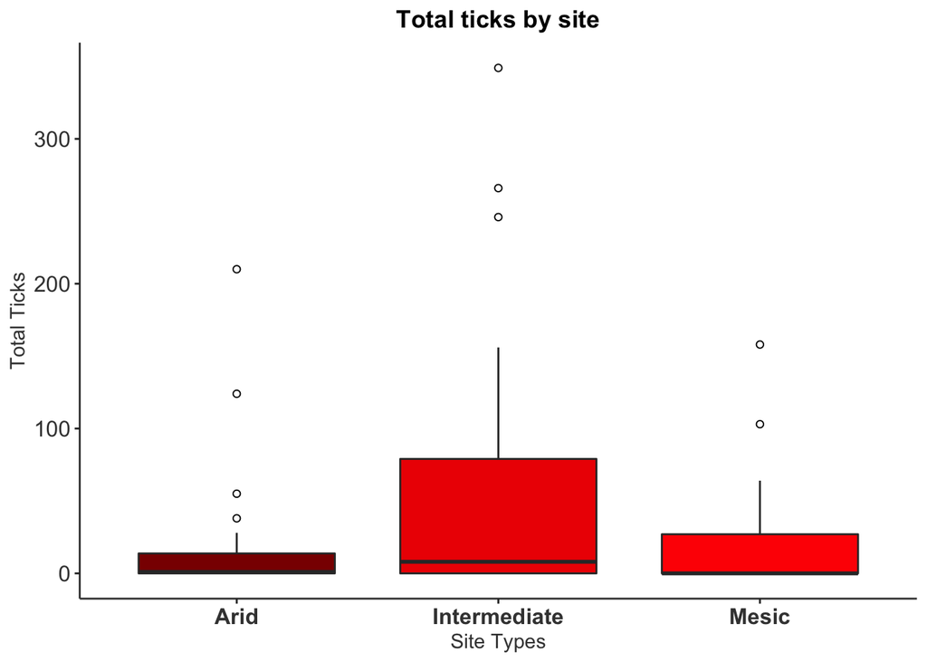

# How does tick abundance (Y) vary by plot types (X)?

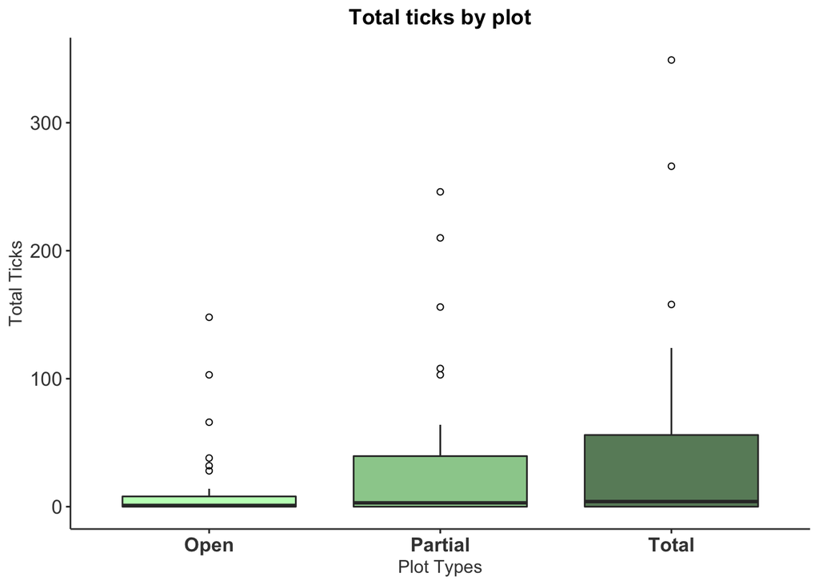

# How does tick abundance (Y) vary by site (X) across plot types (X)?

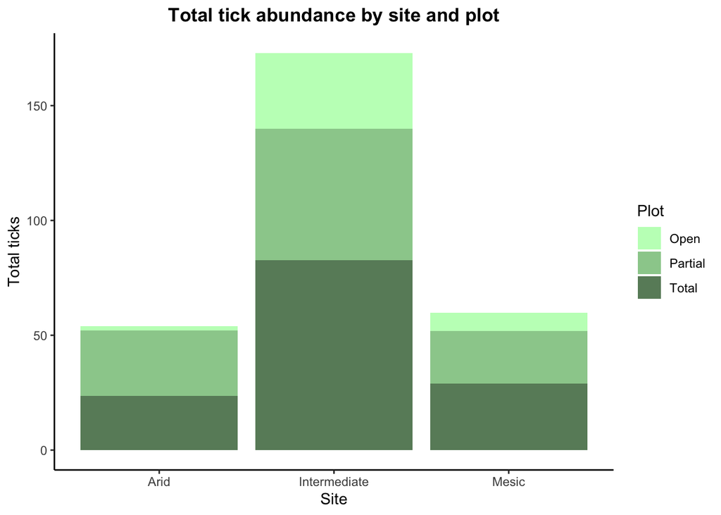

# How does tick abundance (Y) vary by month (X) at each site (X)?

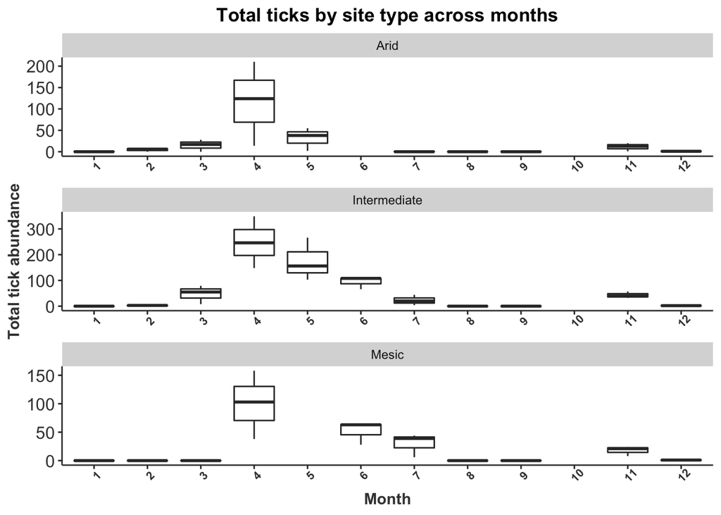

# How does tick abundance (Y) vary by month (X) at each plot type (X) ?

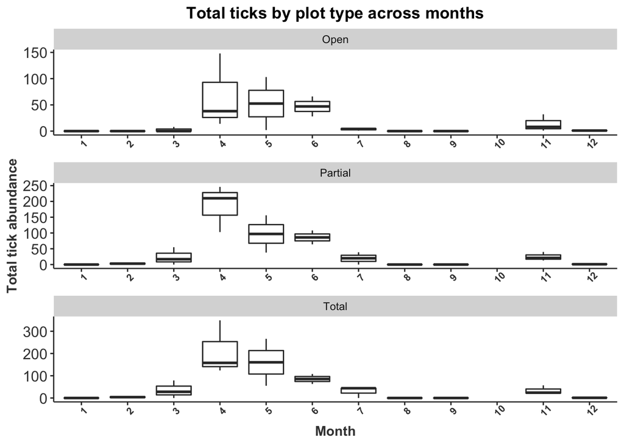

# How does tick abundance (Y) vary by year (X) across site types (X)?

*I know these graphs look wonky on .html, trying to trouble shoot this*

```
## $`1`
```

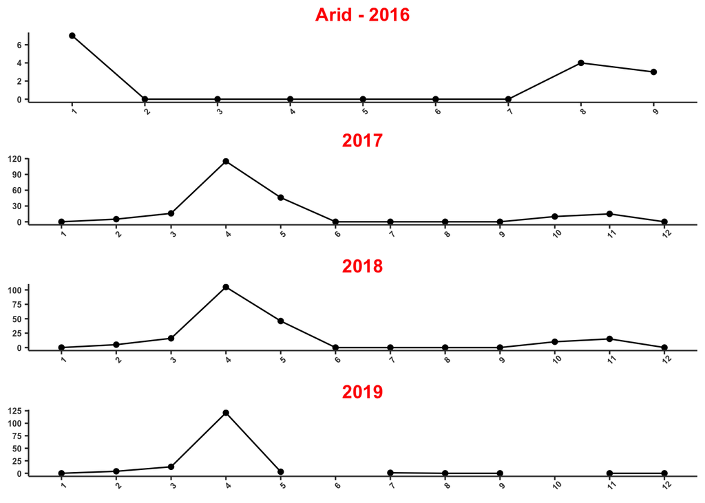

```
##
## $`2`
```

```
##
## attr(,"class")
## [1] "list"      "ggarrange"
```

```
## $`1`
```

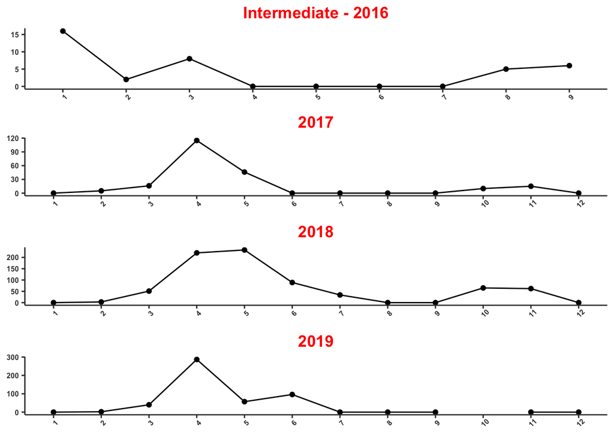

```
##
## $`2`
```

```
##
## attr(,"class")
## [1] "list"      "ggarrange"
```

```
## $`1`
```

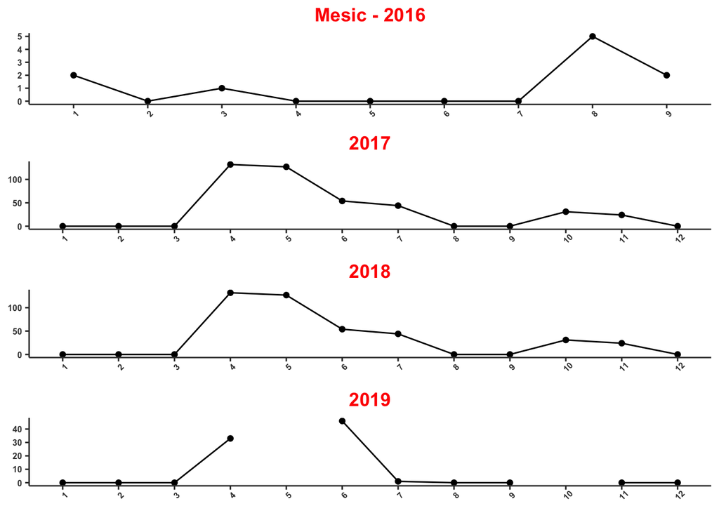

```
##
## $`2`
```

```
##
## attr(,"class")
## [1] "list"      "ggarrange"
```

# How does tick abundance (Y) vary by year (X) across plot types (X)?

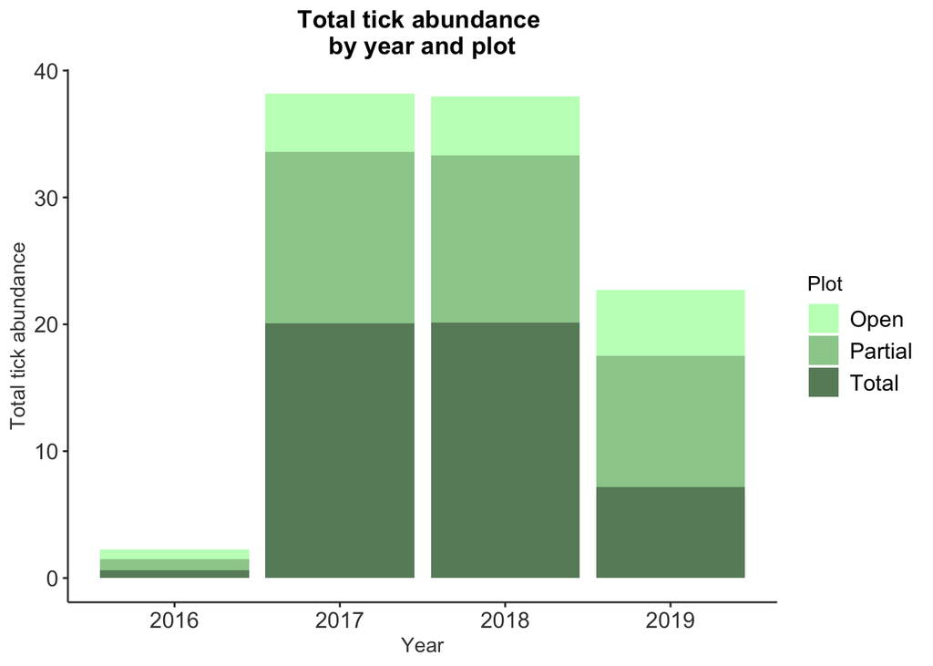

# **Basic Statistics**

**1. Shapiro wilk test**

- **data are not normal (p < 2.2e-16)**
- Poisson distribution of total ticks

**2. Welch's Two sample t-test**

- *a. total tick abundance between arid and mesic sites*
- H0 : mean of total ticks are not different between arid and mesic sites
- **significant difference in tick abundance between arid and mesic site types (p = 0.0008068)**
- *b. total tick abundance between open and total plots*
  - H0 : mean of total ticks are not different between arid and mesic sites
- **significant difference in tick abundance between open and total plot types (p = 2.258e-12)**
- *c. total tick abundance between before and after fence setup*
- H0 : mean of total ticks are not different pre and post fence
  - prefence = year 2016
  - postfence = 2017, 2018, 2019
  - **significant difference in tick abundance pre and post fence (p < 2.2e-16)**

**3. Wilcoxon rank sum test**

- *a. total tick abundance between arid and mesic sites*
- H0 : mean of total ticks are not different between arid and mesic sites
- **significant difference in tick abundance between arid and mesic site types (p = 0.001193)**
- *b. total tick abundance between open and total plots*
- H0 : mean of total ticks are not different between arid and mesic sites
- **significant difference in tick abundance between open and total plot types (p = 1.948e-11)**
- *c. total tick abundance before and after fence*
  - H0 : mean of total ticks are not different pre and post fence
  - prefence = year 2016
  - postfence = 2017, 2018, 2019
  - **significant difference in tick abundance pre and post fence (p < 2.2e-16)**

**4. Kruskal-Wallis tests**

```
##
##  Shapiro-Wilk normality test
##
## data:  alldrag$Total_ticks
## W = 0.51221, p-value < 2.2e-16
```

```
##
##  Welch Two Sample t-test
##
## data:  aridd$Total_ticks and mesicc$Total_ticks
## t = -3.3617, df = 910.87, p-value = 0.0008068
## alternative hypothesis: true difference in means is not equal to 0
## 95 percent confidence interval:
##  -1.2203392 -0.3206864
## sample estimates:
## mean of x mean of y
##  1.244444  2.014957
```

```
##
##  Welch Two Sample t-test
##
## data:  openn$Total_ticks and totall$Total_ticks
## t = -7.1555, df = 649.44, p-value = 2.258e-12
## alternative hypothesis: true difference in means is not equal to 0
## 95 percent confidence interval:
##  -3.209345 -1.827214
## sample estimates:
## mean of x mean of y
##  1.124731  3.643011
```

```
##
##  Welch Two Sample t-test
##
## data:  log(prefence$total_ticks + 1) and log(postfence$total_ticks + 1)
## t = -17.326, df = 1133.4, p-value < 2.2e-16
## alternative hypothesis: true difference in means is not equal to 0
## 95 percent confidence interval:
##  -0.7034190 -0.5603115
## sample estimates:
## mean of x mean of y
## 0.1507513 0.7826166
```

```
##
##  Wilcoxon rank sum test with continuity correction
##
## data:  prefence$total_ticks and postfence$total_ticks
## W = 92584, p-value < 2.2e-16
## alternative hypothesis: true location shift is not equal to 0
```

```
##
##  Wilcoxon rank sum test with continuity correction
##
## data:  aridd$Total_ticks and mesicc$Total_ticks
## W = 93990, p-value = 0.001193
## alternative hypothesis: true location shift is not equal to 0
```

```
##
##  Wilcoxon rank sum test with continuity correction
##
## data:  openn$Total_ticks and totall$Total_ticks
## W = 83968, p-value = 1.948e-11
## alternative hypothesis: true location shift is not equal to 0
```

# Is site a significant predictor of total tick abundances?

- **Yes, site is a significant predictor of total tick abundances**

ANOVA summary:

- H0 : the means of total ticks across all site types are equal
- Fvalue = 39.52
- **p < 2e-16 , reject H0 and conclude that 1 site is significantly different**

Tukey-Kramer:

- **Intermediate is significantly different than arid (p < 1e-04) and mesic (p < 1e-04)**

```
##
##  Shapiro-Wilk normality test
##
## data:  res
## W = 0.63078, p-value < 2.2e-16
```

```
## Levene's Test for Homogeneity of Variance (center = median)
##         Df F value    Pr(>F)
## group    2  39.523 < 2.2e-16 ***
##       1392
## ---
## Signif. codes:  0 '***' 0.001 '**' 0.01 '*' 0.05 '.' 0.1 ' ' 1
```

```
##               Df Sum Sq Mean Sq F value Pr(>F)
## Site           2   2295    1148   39.52 <2e-16 ***
## Residuals   1392  40422      29
## ---
## Signif. codes:  0 '***' 0.001 '**' 0.01 '*' 0.05 '.' 0.1 ' ' 1
## 54 observations deleted due to missingness
```

```
##   Tukey multiple comparisons of means
##     95% family-wise confidence level
##
## Fit: aov(formula = Total_ticks ~ Site, data = alldrag)
##
## $Site
##                          diff         lwr       upr     p adj
## Intermediate-Arid   3.0155136  2.18464895  3.846378 0.0000000
## Mesic-Arid          0.7705128 -0.06422105  1.605247 0.0775259
## Mesic-Intermediate -2.2450008 -3.06760262 -1.422399 0.0000000
```

```
##
##   Simultaneous Tests for General Linear Hypotheses
##
## Multiple Comparisons of Means: Tukey Contrasts
##
##
## Fit: aov(formula = Total_ticks ~ Site, data = alldrag)
##
## Linear Hypotheses:
##                           Estimate Std. Error t value Pr(>|t|)
## Intermediate - Arid == 0    3.0155     0.3541   8.515   <1e-04 ***
## Mesic - Arid == 0           0.7705     0.3558   2.166   0.0776 .
## Mesic - Intermediate == 0  -2.2450     0.3506  -6.403   <1e-04 ***
## ---
## Signif. codes:  0 '***' 0.001 '**' 0.01 '*' 0.05 '.' 0.1 ' ' 1
## (Adjusted p values reported -- single-step method)
```

```
##
##   Simultaneous Confidence Intervals
##
## Multiple Comparisons of Means: Tukey Contrasts
##
##
## Fit: aov(formula = Total_ticks ~ Site, data = alldrag)
##
## Quantile = 2.3463
## 95% family-wise confidence level
##
##
## Linear Hypotheses:
##                           Estimate lwr      upr
## Intermediate - Arid == 0   3.01551  2.18461  3.84642
## Mesic - Arid == 0          0.77051 -0.06427  1.60529
## Mesic - Intermediate == 0 -2.24500 -3.06765 -1.42236
```

```
##         Arid Intermediate        Mesic
##          "a"          "b"          "a"
```

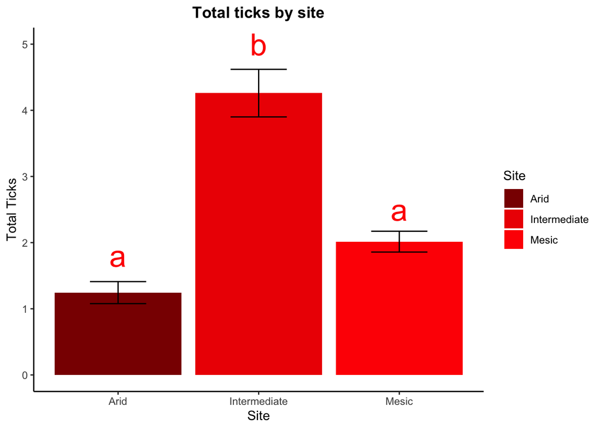

# Is plot type a significant predictor of total tick abundances?

- **Yes, plot is a significant predictor of total tick abundances**

ANOVA summary:

- H0 : the means of total ticks across all site types are equal
- Fvalue = 25.98
- **p = 8.33e-12, reject H0 and conclude that 1 site is significantly different**

Tukey-Kramer:

- **Open is significantly different than partial (p < 1e-04) and total (p < 1e-04)**

```
##
##  Shapiro-Wilk normality test
##
## data:  resp
## W = 0.59572, p-value < 2.2e-16
```

```
##               Df Sum Sq Mean Sq F value   Pr(>F)
## Plot           2   1537   768.7   25.98 8.33e-12 ***
## Residuals   1392  41180    29.6
## ---
## Signif. codes:  0 '***' 0.001 '**' 0.01 '*' 0.05 '.' 0.1 ' ' 1
## 54 observations deleted due to missingness
```

```
##   Tukey multiple comparisons of means
##     95% family-wise confidence level
##
## Fit: aov(formula = Total_ticks ~ Plot, data = alldrag)
##
## $Plot
##                    diff         lwr      upr     p adj
## Partial-Open  1.7096774  0.87276771 2.546587 0.0000054
## Total-Open    2.5182796  1.68136986 3.355189 0.0000000
## Total-Partial 0.8086022 -0.02830756 1.645512 0.0608846
```

```
##
##   Simultaneous Tests for General Linear Hypotheses
##
## Multiple Comparisons of Means: Tukey Contrasts
##
##
## Fit: aov(formula = Total_ticks ~ Plot, data = alldrag)
##
## Linear Hypotheses:
##                      Estimate Std. Error t value Pr(>|t|)
## Partial - Open == 0    1.7097     0.3567   4.793   <1e-04 ***
## Total - Open == 0      2.5183     0.3567   7.060   <1e-04 ***
## Total - Partial == 0   0.8086     0.3567   2.267   0.0609 .
## ---
## Signif. codes:  0 '***' 0.001 '**' 0.01 '*' 0.05 '.' 0.1 ' ' 1
## (Adjusted p values reported -- single-step method)
```

```
##
##   Simultaneous Confidence Intervals
##
## Multiple Comparisons of Means: Tukey Contrasts
##
##
## Fit: aov(formula = Total_ticks ~ Plot, data = alldrag)
##
## Quantile = 2.3466
## 95% family-wise confidence level
##
##
## Linear Hypotheses:
##                      Estimate lwr      upr
## Partial - Open == 0   1.70968  0.87264  2.54671
## Total - Open == 0     2.51828  1.68124  3.35532
## Total - Partial == 0  0.80860 -0.02843  1.64564
```

```
##    Open Partial   Total
##     "a"     "b"     "b"
```

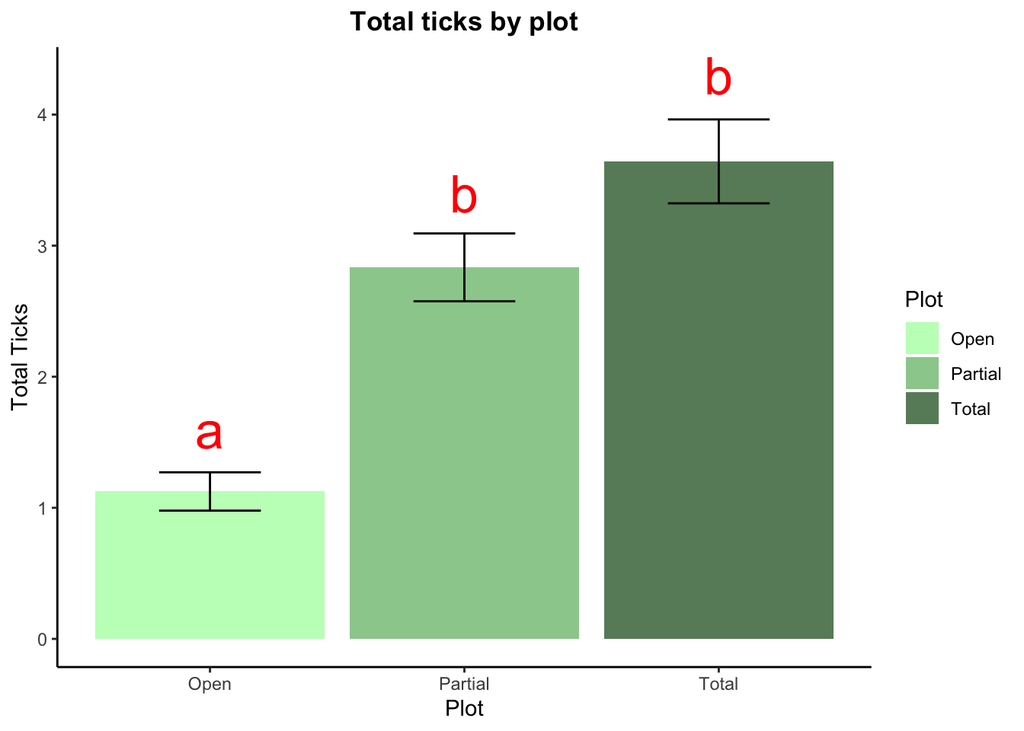

# Is year a significant predictor of total tick abundances?

**Yes, year is a significant predictor of total tick abundances**

ANOVA summary:

- H0 : the means of total ticks across all site types are equal
- Fvalue = 21.63
- **p = 1.08e-13, reject H0 and conclude that 1 site is significantly different**

Tukey-Kramer:

- **2016 is significantly different than 2017 (p < 0.001), 2018 (p < 0.001), 2019 (p < 0.001)**
- **2017 and 2018 are significantly different than 2016 (p < 0.001) and 2019 (p = 0.00921, p = 0.01091 )**

```
##
##  Shapiro-Wilk normality test
##
## data:  resy
## W = 0.58465, p-value < 2.2e-16
```

```
##               Df Sum Sq Mean Sq F value   Pr(>F)
## Year           3   1904   634.7   21.63 1.08e-13 ***
## Residuals   1391  40813    29.3
## ---
## Signif. codes:  0 '***' 0.001 '**' 0.01 '*' 0.05 '.' 0.1 ' ' 1
## 54 observations deleted due to missingness
```

```
## [1] "factor"
```

```
## [1] "factor"
```

```
##   Tukey multiple comparisons of means
##     95% family-wise confidence level
##
## Fit: aov(formula = Total_ticks ~ Year, data = alldrag)
##
## $Year
##                  diff        lwr        upr     p adj
## 2017-2016  3.14403292  2.0134878  4.2745781 0.0000000
## 2018-2016  3.12181070  1.9912655  4.2523559 0.0000000
## 2019-2016  1.89224605  0.7233045  3.0611876 0.0001946
## 2018-2017 -0.02222222 -1.0013031  0.9568586 0.9999286
## 2019-2017 -1.25178687 -2.2749639 -0.2286098 0.0091320
## 2019-2018 -1.22956465 -2.2527417 -0.2063876 0.0109421
```

```
##
##   Simultaneous Tests for General Linear Hypotheses
##
## Multiple Comparisons of Means: Tukey Contrasts
##
##
## Fit: aov(formula = Total_ticks ~ Year, data = alldrag)
##
## Linear Hypotheses:
##                  Estimate Std. Error t value Pr(>|t|)
## 2017 - 2016 == 0  3.14403    0.43953   7.153  < 0.001 ***
## 2018 - 2016 == 0  3.12181    0.43953   7.103  < 0.001 ***
## 2019 - 2016 == 0  1.89225    0.45446   4.164  < 0.001 ***
## 2018 - 2017 == 0 -0.02222    0.38065  -0.058  0.99993
## 2019 - 2017 == 0 -1.25179    0.39779  -3.147  0.00901 **
## 2019 - 2018 == 0 -1.22956    0.39779  -3.091  0.01086 *
## ---
## Signif. codes:  0 '***' 0.001 '**' 0.01 '*' 0.05 '.' 0.1 ' ' 1
## (Adjusted p values reported -- single-step method)
```

```
##
##   Simultaneous Confidence Intervals
##
## Multiple Comparisons of Means: Tukey Contrasts
##
##
## Fit: aov(formula = Total_ticks ~ Year, data = alldrag)
##
## Quantile = 2.5686
## 95% family-wise confidence level
##
##
## Linear Hypotheses:
##                  Estimate lwr      upr
## 2017 - 2016 == 0  3.14403  2.01504  4.27303
## 2018 - 2016 == 0  3.12181  1.99282  4.25080
## 2019 - 2016 == 0  1.89225  0.72491  3.05958
## 2018 - 2017 == 0 -0.02222 -0.99996  0.95551
## 2019 - 2017 == 0 -1.25179 -2.27356 -0.23002
## 2019 - 2018 == 0 -1.22956 -2.25134 -0.20779
```

```
## 2016 2017 2018 2019
##  "a"  "c"  "c"  "b"
```

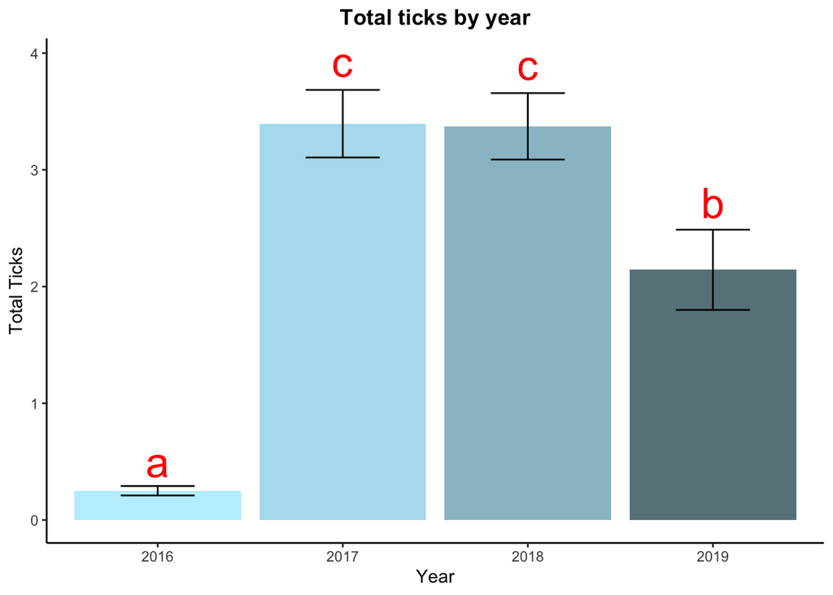

# Is month a significant predictor of total tick abundances?

**Yes, month is a significant predictor of total tick abundances**

ANOVA summary:

- H0 : the means of total ticks across all site types are equal
- Fvalue = 24.85
- **p <2e-16, reject H0 and conclude that 1 site is significantly different**

Tukey-Kramer:

- *This analysis is a little more messy, but there are months that are significantly different from each other*
- **Specifically, April is different from every month except May**

```
##
##  Shapiro-Wilk normality test
##
## data:  resm
## W = 0.6516, p-value < 2.2e-16
```

```
## Levene's Test for Homogeneity of Variance (center = median)
##         Df F value    Pr(>F)
## group   11  23.208 < 2.2e-16 ***
##       1383
## ---
## Signif. codes:  0 '***' 0.001 '**' 0.01 '*' 0.05 '.' 0.1 ' ' 1
```

```
##               Df Sum Sq Mean Sq F value Pr(>F)
## Month         11   7050   640.9   24.85 <2e-16 ***
## Residuals   1383  35667    25.8
## ---
## Signif. codes:  0 '***' 0.001 '**' 0.01 '*' 0.05 '.' 0.1 ' ' 1
## 54 observations deleted due to missingness
```

```
##   January  February     March     April       May      June      July    August
##       "a"      "ab"      "ac"       "e"      "de"      "cd"      "ab"       "a"
## September   October  November  December
##       "a"      "bc"      "ac"       "a"
```

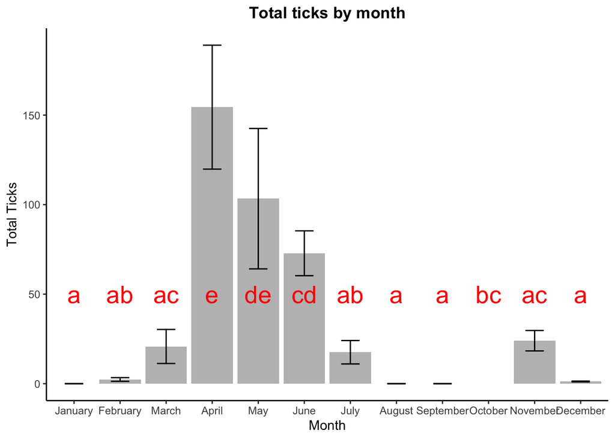

# **Generalized Linear Models**

# What are good predictors (X) of total tick abundance (Y)?

**Ran *generalized linear models* because data breaks assumptions of normality. Used family poisson because of count data.**

*Object **'tickmodels'** is table of df, AIC, BIC, variables used in glm models*

models : tick1 - tick7

|  | df | AIC | BIC | variables |
| --- | --- | --- | --- | --- |
| tick1 | 4 | 10475.62 | 10496.58 | Year |
| tick2 | 3 | 10649.35 | 10665.08 | Site |
| tick3 | 3 | 10856.14 | 10871.86 | Plot |
| tick4 | 12 | 8084.50 | 8147.39 | Month |
| tick5 | 6 | 9584.32 | 9615.77 | Site + Year |
| tick6 | 8 | 8912.88 | 8954.80 | Site + Year + Plot |
| tick7 | 19 | 5683.05 | 5782.62 | Site + Year + Plot + Month |

# Data - Mammal Analysis

Excel sheets called

- 'tejon_mammals1819_09022020'
- 'tejon_mammalcount_09032020'

*Notes*

- in these datasheets I name columns with lowercase compared to tick data sheets (i.e. month not Month)

# **Exploratory Data Analysis**

# How does mammal abudance (Y) vary across site type (X)?

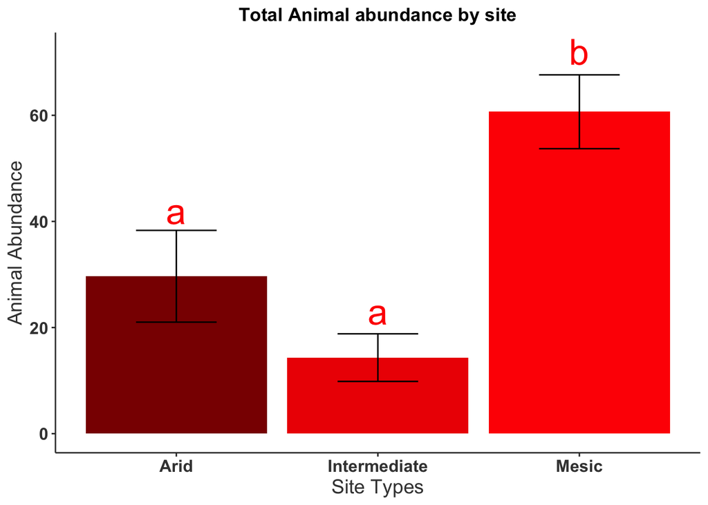

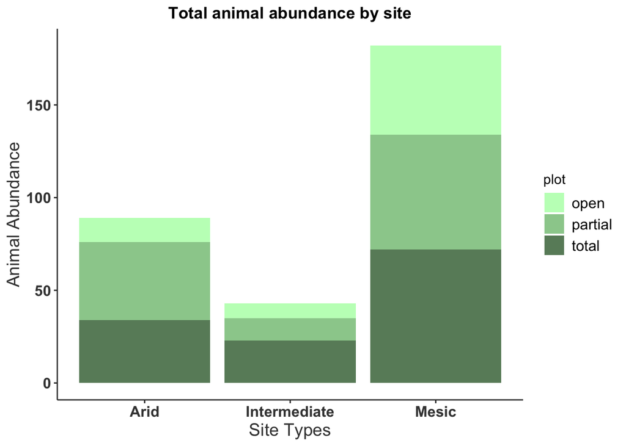

# How does mammal abudance (Y) vary across plot type (X)?

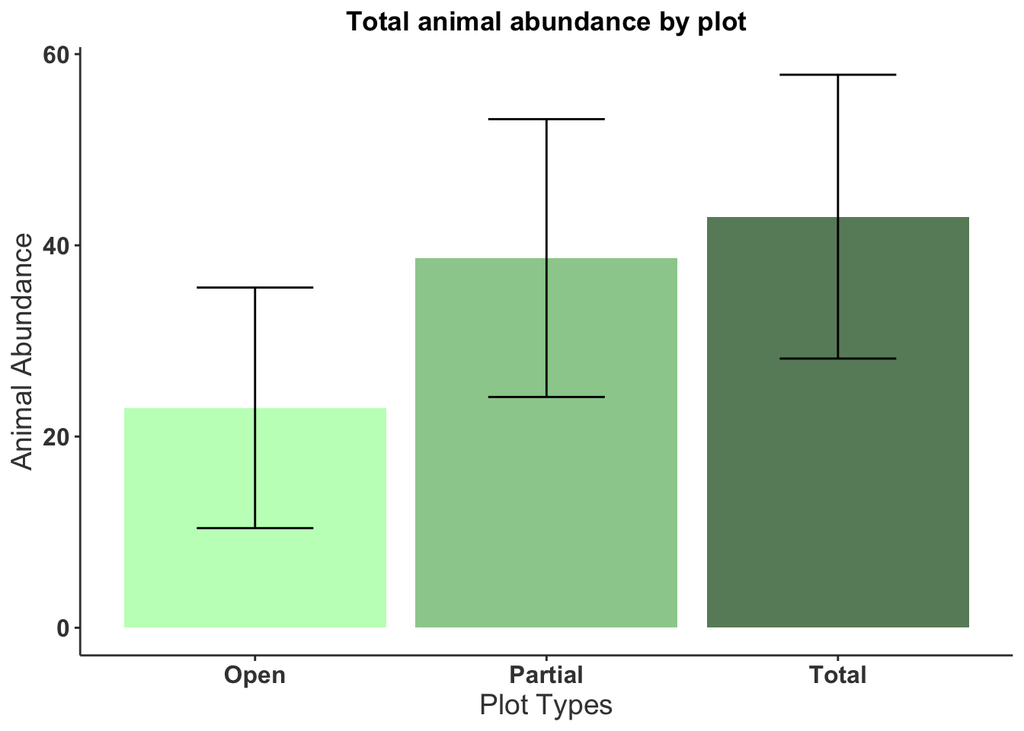

# How does mammal species richness (Y) vary by site type (X)?

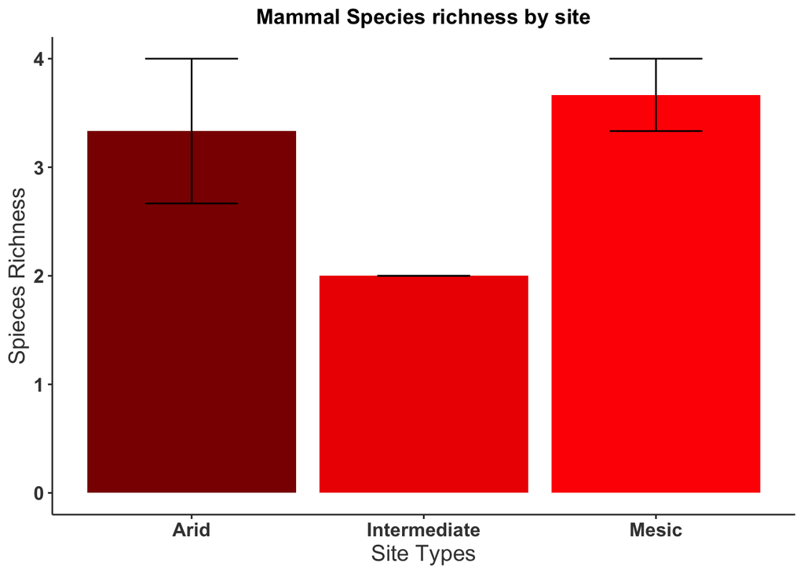

# How does mammal species richness(Y) vary by plot type (X)?

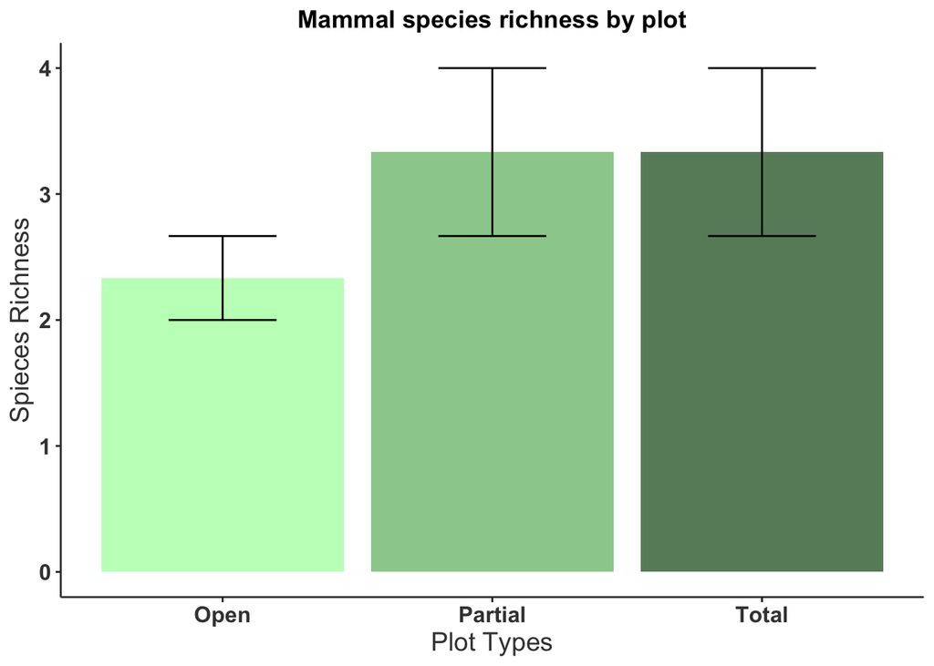

# How does shannon diversity (Y) vary by site types (X)?

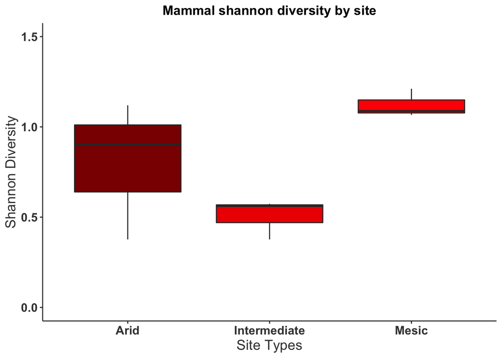

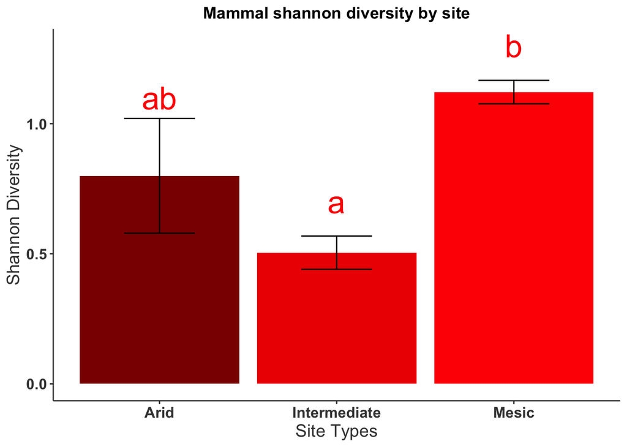

# How does shannon diversity (Y) vary by plot types (X)?

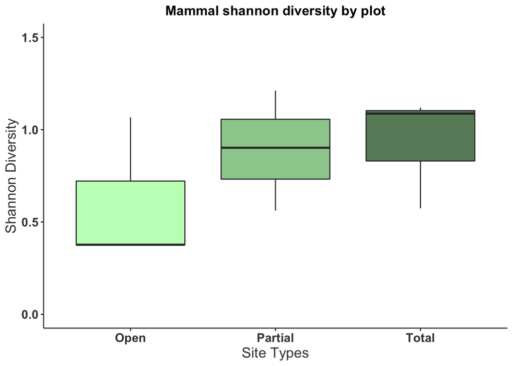

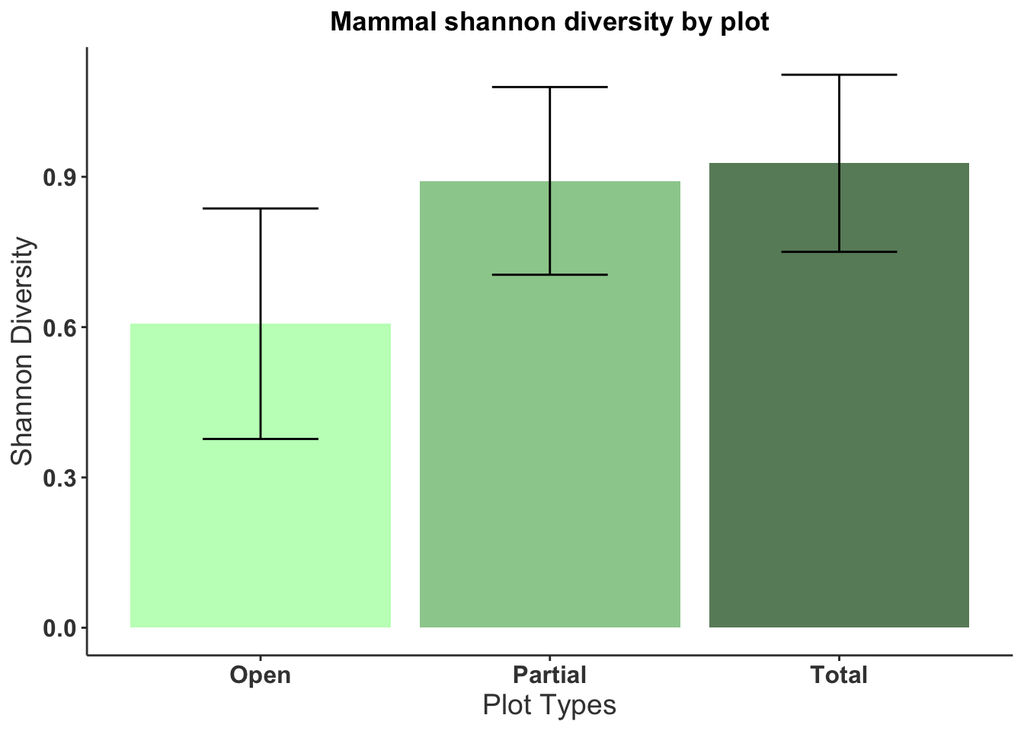

# **Basic Statistics**

**1. Shapiro wilk test**

- **data are normal (p = 0.5137)**

```
##
##  Shapiro-Wilk normality test
##
## data:  count$total
## W = 0.93333, p-value = 0.5137
```

# **ANOVAS**

**Only significant variable on total mammal abundances was site, not plot**

```
## Analysis of Variance Table
##
## Response: total
##           Df Sum Sq Mean Sq F value Pr(>F)
## plot       2  664.2  332.11  0.5631 0.5969
## Residuals  6 3538.7  589.78
```

```
## Analysis of Variance Table
##
## Response: sppr
##           Df Sum Sq Mean Sq F value Pr(>F)
## plot       2      2       1       1 0.4219
## Residuals  6      6       1
```

```
## Analysis of Variance Table
##
## Response: shannondiv
##           Df  Sum Sq  Mean Sq F value Pr(>F)
## plot       2 0.18504 0.092519   0.776 0.5015
## Residuals  6 0.71532 0.119220
```

```
## Analysis of Variance Table
##
## Response: total
##           Df Sum Sq Mean Sq F value   Pr(>F)
## site       2 3342.9 1671.44  11.661 0.008567 **
## Residuals  6  860.0  143.33
## ---
## Signif. codes:  0 '***' 0.001 '**' 0.01 '*' 0.05 '.' 0.1 ' ' 1
```

```
## Analysis of Variance Table
##
## Response: sppr
##           Df Sum Sq Mean Sq F value  Pr(>F)
## site       2 4.6667 2.33333     4.2 0.07234 .
## Residuals  6 3.3333 0.55556
## ---
## Signif. codes:  0 '***' 0.001 '**' 0.01 '*' 0.05 '.' 0.1 ' ' 1
```

```
## Analysis of Variance Table
##
## Response: shannondiv
##           Df  Sum Sq  Mean Sq F value  Pr(>F)
## site       2 0.57199 0.285994  5.2256 0.04851 *
## Residuals  6 0.32837 0.054729
## ---
## Signif. codes:  0 '***' 0.001 '**' 0.01 '*' 0.05 '.' 0.1 ' ' 1
```

# Is site a significant predictor of total mammal abundances?

**Yes, site is a significant predictor of total tick abundances**

ANOVA summary:

- H0 : the means of total ticks across all site types are equal
- Fvalue = 11.66
- **p = 0.00857, reject H0 and conclude that 1 site is significantly different**

Tukey-Kramer:

- **Mesic is significantly different than arid (p = 0.04407) and intermediate (p = 0.00737)**

```
##
##  Shapiro-Wilk normality test
##
## data:  res4
## W = 0.94187, p-value = 0.6017
```

```
## Levene's Test for Homogeneity of Variance (center = median)
##       Df F value Pr(>F)
## group  2  0.2577  0.781
##        6
```

```
##             Df Sum Sq Mean Sq F value  Pr(>F)
## site         2   3343  1671.4   11.66 0.00857 **
## Residuals    6    860   143.3
## ---
## Signif. codes:  0 '***' 0.001 '**' 0.01 '*' 0.05 '.' 0.1 ' ' 1
```

```
##   Tukey multiple comparisons of means
##     95% family-wise confidence level
##
## Fit: aov(formula = total ~ site, data = count)
##
## $site
##                         diff        lwr      upr     p adj
## intermediate-arid  -15.33333 -45.326490 14.65982 0.3279565
## mesic-arid          31.00000   1.006844 60.99316 0.0440702
## mesic-intermediate  46.33333  16.340177 76.32649 0.0076191
```

```
##
##   Simultaneous Tests for General Linear Hypotheses
##
## Multiple Comparisons of Means: Tukey Contrasts
##
##
## Fit: aov(formula = total ~ site, data = count)
##
## Linear Hypotheses:
##                           Estimate Std. Error t value Pr(>|t|)
## intermediate - arid == 0   -15.333      9.775  -1.569  0.32791
## mesic - arid == 0           31.000      9.775   3.171  0.04418 *
## mesic - intermediate == 0   46.333      9.775   4.740  0.00741 **
## ---
## Signif. codes:  0 '***' 0.001 '**' 0.01 '*' 0.05 '.' 0.1 ' ' 1
## (Adjusted p values reported -- single-step method)
```

```
##
##   Simultaneous Confidence Intervals
##
## Multiple Comparisons of Means: Tukey Contrasts
##
##
## Fit: aov(formula = total ~ site, data = count)
##
## Quantile = 3.0661
## 95% family-wise confidence level
##
##
## Linear Hypotheses:
##                           Estimate lwr      upr
## intermediate - arid == 0  -15.3333 -45.3056  14.6389
## mesic - arid == 0          31.0000   1.0277  60.9723
## mesic - intermediate == 0  46.3333  16.3611  76.3056
```

```
##         arid intermediate        mesic
##          "a"          "a"          "b"
```

# Is site a significant predictor of mammal shannon diversity?

**Yes, site is a significant predictor of mammal shannon diversity**

ANOVA summary:

- H0 : the means of total ticks across all site types are equal
- Fvalue = 5.226
- **p = 0.0485, reject H0 and conclude that 1 site is significantly different**

Tukey-Kramer:

- **Mesic is significantly different than intermediate (p = 0.0415)**

```
##
##  Shapiro-Wilk normality test
##
## data:  res6
## W = 0.92262, p-value = 0.4144
```

```
## Levene's Test for Homogeneity of Variance (center = median)
##       Df F value Pr(>F)
## group  2  1.2935 0.3411
##        6
```

```
##             Df Sum Sq Mean Sq F value Pr(>F)
## site         2 0.5720 0.28599   5.226 0.0485 *
## Residuals    6 0.3284 0.05473
## ---
## Signif. codes:  0 '***' 0.001 '**' 0.01 '*' 0.05 '.' 0.1 ' ' 1
```

```
##   Tukey multiple comparisons of means
##     95% family-wise confidence level
##
## Fit: aov(formula = shannondiv ~ site, data = count)
##
## $site
##                          diff         lwr       upr     p adj
## intermediate-arid  -0.2951600 -0.88124120 0.2909211 0.3371220
## mesic-arid          0.3221582 -0.26392301 0.9082393 0.2846931
## mesic-intermediate  0.6173182  0.03123702 1.2033994 0.0409416
```

```
##
##   Simultaneous Tests for General Linear Hypotheses
##
## Multiple Comparisons of Means: Tukey Contrasts
##
##
## Fit: aov(formula = shannondiv ~ site, data = count)
##
## Linear Hypotheses:
##                           Estimate Std. Error t value Pr(>|t|)
## intermediate - arid == 0   -0.2952     0.1910  -1.545   0.3372
## mesic - arid == 0           0.3222     0.1910   1.687   0.2848
## mesic - intermediate == 0   0.6173     0.1910   3.232   0.0413 *
## ---
## Signif. codes:  0 '***' 0.001 '**' 0.01 '*' 0.05 '.' 0.1 ' ' 1
## (Adjusted p values reported -- single-step method)
```

```
##
##   Simultaneous Confidence Intervals
##
## Multiple Comparisons of Means: Tukey Contrasts
##
##
## Fit: aov(formula = shannondiv ~ site, data = count)
##
## Quantile = 3.0653
## 95% family-wise confidence level
##
##
## Linear Hypotheses:
##                           Estimate lwr      upr
## intermediate - arid == 0  -0.29516 -0.88067  0.29035
## mesic - arid == 0          0.32216 -0.26335  0.90767
## mesic - intermediate == 0  0.61732  0.03181  1.20283
```

```
##         arid intermediate        mesic
##         "ab"          "a"          "b"
```

PCA plot

- honestly these are not as clear, but willing to keep working on them if people are interested

PCA1 = count by species

```
## Importance of components:
##                           PC1    PC2    PC3    PC4     PC5     PC6
## Standard deviation     1.5920 1.3519 0.9300 0.7992 0.35905 0.07417
## Proportion of Variance 0.4224 0.3046 0.1442 0.1065 0.02149 0.00092
## Cumulative Proportion  0.4224 0.7270 0.8711 0.9776 0.99908 1.00000
```

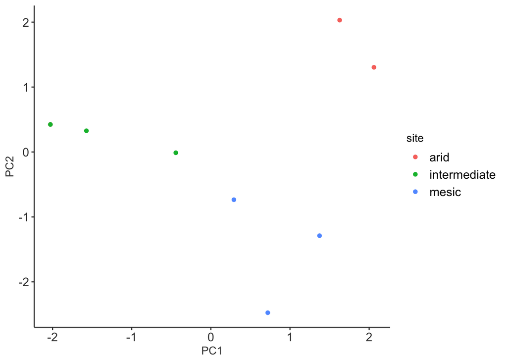

## Data - Combination of ticks and mammals

Excel sheet 'tejon_tickmammal_09032020'

Has tick and mammmal data combined with calculated species richness and shannondiversity metrics associated with each site

# **Generalized Linear Regression models**

models : tick20 - tick25

- **Lowest AIC for *multivariables* is tick24 (total_tick ~ site, year, plot)**
- ** Lowest AIC for *singularvariable* is tick20 (total_tick ~ year) **

models : mammal13 - mammal18

- **Lowest AIC for *multivariables* is mammal17 (total_mammal ~ site, year, plot)**
- **Lowest AIC for *singularvariable* is mammal14 (total_mammal ~ site)**

models : combo7 - combo12

Graphs/ Tables with df, AIC, BIC, rsq, adj_rsq, variables

- 1. tickmodel_glm
- 2. mammalmodel_glm
- 3. combomodel_glm

**Generalized linear regression models for total tick abundance**

|  | df | AIC | BIC | variables |
| --- | --- | --- | --- | --- |
| tick20 | 4 | 10475.62 | 10496.58 | Year |
| tick21 | 3 | 12297.52 | 12313.36 | Site |
| tick22 | 3 | 24593.92 | 24609.76 | Plot |
| tick23 | 6 | 12303.52 | 12335.19 | Site + Year |
| tick24 | 8 | 9057.98 | 9100.21 | Site + Year + Plot |
| tick25 | 19 | 9079.98 | 9180.27 | Site + Year + Plot + Month |

**Generalized linear regression models for total mammal abundance**

|  | df | AIC | BIC | variables |
| --- | --- | --- | --- | --- |
| mammal13 | 4 | 27845.35 | 27866.46 | Year |
| mammal14 | 3 | 12297.52 | 12313.36 | Site |
| mammal15 | 3 | 24593.92 | 24609.76 | Plot |
| mammal16 | 6 | 12303.52 | 12335.19 | Site + Year |
| mammal17 | 8 | 9057.98 | 9100.21 | Site + Year + Plot |
| mammal18 | 19 | 9079.98 | 9180.27 | Site + Year + Plot + Month |

**Generalized linear regression models for tick abundance with mammal variables**

|  | df | AIC | BIC | variables |
| --- | --- | --- | --- | --- |
| combo7 | 2 | 11498.87 | 11509.35 | Total Mammal |
| combo8 | 2 | 11391.47 | 11401.95 | Mammal Species Richness |
| combo9 | 2 | 11421.58 | 11432.06 | Mammal Shannon Diversity |
| combo10 | 3 | 11371.02 | 11386.74 | Shannon + Total |
| combo11 | 20 | 5681.62 | 5786.43 | Site + Year + Plot + Shannon |
| combo12 | 21 | 5555.66 | 5665.71 | Site + Year + Plot + Shannon + Total |

# **Zero Inflated hurdle models**

- Neither total tick or mammal counts are normally distributed (shapiro.test p << 0.05, meaning data not normal).
- The models are based on Poisson and Negative binomial distribution are expecting count data (integer values only).

Hurdle model: treat as 2 part process

- 1st part is 0
- 2nd part is non-zero

Zero inflated Poisson (ZIP):

- Two types of 0s : good and bad
  - variance = mean

Zero inflated negative binomial (ZINB):

- Negative binomial version is more significant than poisson

Models

**1. ZIP_round_down (poisson - tick counts)**

- Site was a significant predictor of total tick counts **p = 1.73e-8**
- Plot was a significant predictor of total tick counts **p < 2e-16**
- Year was a significant predictor of total tick counts **p < 2e-16**

**2. H1downB (negative binomial - tick counts)**

- Site Intermidate was a significant predictor of total tick counts **p = 2e-16**
- Site Mesic was a significant predictor of total tick counts **p = 4.59e-5**
- Plot Partial was a significant predictor of total tick counts **p = 3.37e-13**
- Plot Total was a significant predictor of total tick counts **p < 2e-16**
- Year was a significant predictor of total tick counts **p < 2e-16**

**3. ZIP_round_downmam (poisson - mammal counts)**

*need to double check if this is applicable to mammal counts, I think how I currently have the dataframet set up this may not be appropriate*

- Site was a significant predictor of total mammal counts **p = 1.73e-8**
- Plot was a significant predictor of total mammal counts **p < 2e-16**
- Year was a significant predictor of total mammal counts **p < 2e-16**

**4. H1downB (negative binomial - mammal counts)**

- Site Intermidate was a significant predictor of total mammal counts **p = 2e-16**
- Site Mesic was a significant predictor of total mammal counts **p = 0.00824**
- Plot Partial was a significant predictor of total mammal counts **p = 0.02398**
- Year was a significant predictor of total mammal counts **p < 2e-16**

```
## [1] 879
```

```
##
##  Shapiro-Wilk normality test
##
## data:  combo$total_ticks
## W = 0.51221, p-value < 2.2e-16
```

```
## [1] 6
```

```
##
##  Shapiro-Wilk normality test
##
## data:  combo$total_mammal
## W = 0.89443, p-value < 2.2e-16
```

```
## [1] 8
```

```
## [1] 72
```

```
## [1] 1456
```

```
## [1] 0.004120879
```

```
## [1] 34.9131
```

```
##
## Call:
## zeroinfl(formula = fldown, data = combo, dist = "poisson", link = "logit")
##
## Pearson residuals:
##     Min      1Q  Median      3Q     Max
## -0.9885 -0.7605 -0.5568  0.2586 20.7760
##
## Count model coefficients (poisson with log link):
##                  Estimate Std. Error z value Pr(>|z|)
## (Intercept)       0.46978    0.06691   7.021  2.2e-12 ***
## siteIntermediate  1.05708    0.05081  20.804  < 2e-16 ***
## siteMesic         0.47272    0.05642   8.379  < 2e-16 ***
## plotPartial       0.69892    0.05490  12.730  < 2e-16 ***
## plotTotal         0.94234    0.05332  17.675  < 2e-16 ***
##
## Zero-inflation model coefficients (binomial with logit link):
##                  Estimate Std. Error z value Pr(>|z|)
## (Intercept)        0.8864     0.1439   6.158 7.39e-10 ***
## siteIntermediate  -0.4723     0.1410  -3.349 0.000810 ***
## siteMesic         -0.1732     0.1431  -1.210 0.226145
## plotPartial       -0.5297     0.1427  -3.712 0.000206 ***
## plotTotal         -0.5586     0.1423  -3.925 8.68e-05 ***
## ---
## Signif. codes:  0 '***' 0.001 '**' 0.01 '*' 0.05 '.' 0.1 ' ' 1
##
## Number of iterations in BFGS optimization: 14
## Log-likelihood: -3138 on 10 Df
```

```
##
## Call:
## zeroinfl(formula = fldown, data = combo, dist = "negbin", link = "logit")
##
## Pearson residuals:
##     Min      1Q  Median      3Q     Max
## -0.5780 -0.5450 -0.4740  0.1495 16.1089
##
## Count model coefficients (negbin with log link):
##                  Estimate Std. Error z value Pr(>|z|)
## (Intercept)       -0.3905     0.1612  -2.423   0.0154 *
## siteIntermediate   1.4648     0.1352  10.832  < 2e-16 ***
## siteMesic          0.6742     0.1371   4.919 8.71e-07 ***
## plotPartial        1.1810     0.1266   9.330  < 2e-16 ***
## plotTotal          1.3309     0.1223  10.879  < 2e-16 ***
## Log(theta)        -0.2476     0.1404  -1.763   0.0779 .
##
## Zero-inflation model coefficients (binomial with logit link):
##                  Estimate Std. Error z value Pr(>|z|)
## (Intercept)       -0.4849     0.2428  -1.997   0.0458 *
## siteIntermediate   0.1055     0.2353   0.448   0.6539
## siteMesic          0.1816     0.2417   0.751   0.4525
## ---
## Signif. codes:  0 '***' 0.001 '**' 0.01 '*' 0.05 '.' 0.1 ' ' 1
##
## Theta = 0.7807
## Number of iterations in BFGS optimization: 16
## Log-likelihood: -2399 on 9 Df
```

```
## Likelihood ratio test
##
## Model 1: total_ticks ~ site + plot | site + plot
## Model 2: total_ticks ~ site + plot | site
##   #Df  LogLik Df  Chisq Pr(>Chisq)
## 1  10 -3138.5
## 2   9 -2399.1 -1 1478.8  < 2.2e-16 ***
## ---
## Signif. codes:  0 '***' 0.001 '**' 0.01 '*' 0.05 '.' 0.1 ' ' 1
```

```
## Likelihood ratio test
##
## Model 1: total_ticks ~ site + plot | site
## Model 2: total_ticks ~ site + plot | site
##   #Df  LogLik Df  Chisq Pr(>Chisq)
## 1   8 -3158.0
## 2   9 -2419.1  1 1477.9  < 2.2e-16 ***
## ---
## Signif. codes:  0 '***' 0.001 '**' 0.01 '*' 0.05 '.' 0.1 ' ' 1
```

```
##
## Call:
## hurdle(formula = fldown, data = combo, dist = "negbin", link = "logit")
##
## Pearson residuals:
##     Min      1Q  Median      3Q     Max
## -0.5967 -0.5461 -0.4898  0.2234 16.4103
##
## Count model coefficients (truncated negbin with log link):
##                  Estimate Std. Error z value Pr(>|z|)
## (Intercept)       -0.1830     0.1749  -1.047    0.295
## siteIntermediate   1.3439     0.1360   9.879  < 2e-16 ***
## siteMesic          0.5595     0.1373   4.076 4.59e-05 ***
## plotPartial        1.0415     0.1431   7.279 3.37e-13 ***
## plotTotal          1.2042     0.1381   8.717  < 2e-16 ***
## Log(theta)        -0.2172     0.1422  -1.527    0.127
## Zero hurdle model coefficients (binomial with logit link):
##                  Estimate Std. Error z value Pr(>|z|)
## (Intercept)       -0.6435     0.0992  -6.487 8.75e-11 ***
## siteIntermediate   0.5890     0.1350   4.362 1.29e-05 ***
## siteMesic          0.2630     0.1368   1.923   0.0545 .
## ---
## Signif. codes:  0 '***' 0.001 '**' 0.01 '*' 0.05 '.' 0.1 ' ' 1
##
## Theta: count = 0.8048
## Number of iterations in BFGS optimization: 14
## Log-likelihood: -2419 on 9 Df
```

[output not shown]

```
## Likelihood ratio test
##
## Model 1: total_ticks ~ site + plot + total_mammal | year
## Model 2: total_ticks ~ site + plot + total_mammal | year
##   #Df  LogLik Df  Chisq Pr(>Chisq)
## 1  10 -3074.5
## 2  11 -2358.2  1 1432.6  < 2.2e-16 ***
## ---
## Signif. codes:  0 '***' 0.001 '**' 0.01 '*' 0.05 '.' 0.1 ' ' 1
```

```
##
## Call:
## hurdle(formula = fldownmam, data = combo, dist = "negbin", link = "logit")
##
## Pearson residuals:
##     Min      1Q  Median      3Q     Max
## -0.8033 -0.6073 -0.3593  0.1508 12.9099
##
## Count model coefficients (truncated negbin with log link):
##                  Estimate Std. Error z value Pr(>|z|)
## (Intercept)      -1.41649    0.32578  -4.348 1.37e-05 ***
## siteIntermediate  2.32703    0.25239   9.220  < 2e-16 ***
## siteMesic        -0.94048    0.35596  -2.642  0.00824 **
## plotPartial       0.42325    0.18749   2.257  0.02398 *
## plotTotal         0.32676    0.23157   1.411  0.15823
## total_mammal      0.05311    0.01157   4.591 4.40e-06 ***
## Log(theta)       -0.14372    0.13797  -1.042  0.29756
## Zero hurdle model coefficients (binomial with logit link):
##             Estimate Std. Error z value Pr(>|z|)
## (Intercept)  -1.5091     0.1666  -9.059  < 2e-16 ***
## year2017      1.6228     0.1941   8.362  < 2e-16 ***
## year2018      1.6228     0.1941   8.362  < 2e-16 ***
## year2019      0.6950     0.2037   3.412 0.000645 ***
## ---
## Signif. codes:  0 '***' 0.001 '**' 0.01 '*' 0.05 '.' 0.1 ' ' 1
##
## Theta: count = 0.8661
## Number of iterations in BFGS optimization: 15
## Log-likelihood: -2358 on 11 Df
```